# Supports graphiques du journal du Stress Hydrique

Manon Tobias - m.tobias@institut-rhodanien.com

2024-08-12

# Journal du stress hydrique

L’état de la contrainte hydrique globale au vignoble se trouve désormais couplée à un point plus général sur la vie du vignoble, dans Vision de Vignes. Vous pouvez y accéder en suivant [**ce lien**](https://www.institut-rhodanien.com/article/vision-de-vignes-2024) .

Sur cette page, vous trouverez les graphiques et les informations brutes issus de notre suivi de la contrainte hydrique sur notre réseau. Plusieurs indicateurs sont suivis, de manière non systématique en fonction des parcelles. Ainsi, vous pourrez consulter :  
- Un point météo  
- Le bilan hydrique et les simulations de l’évolution des réserves en eau dans les sols pour les zones qui vous concernent  
- Les suivis d’apex  
- Les données des sondes capacitives, si les parcelles sont équipées  
- Les données d’un tensiomètre installé à Vénéjan, pour avoir des informations complémentaires

Les parcelles suivies sont les suivantes:

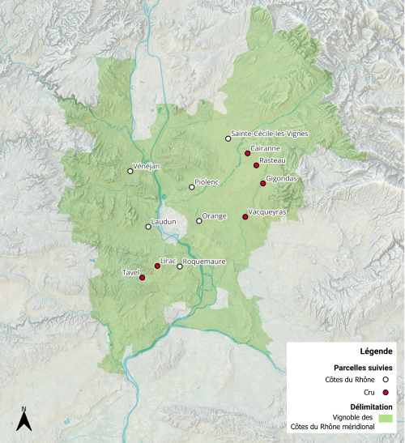

# Météo

Le territoire des Côtes du Rhône vit son deuxième épisode caniculaire de l’été, une semaine le séparant du dernier en date. Le graphique des températures sur Orange nous montre l’intensité de ces phénomènes. La moyenne des températures (en rouge) se situait en effet, jusqu’à présent dans les “normales”. Depuis 2/3 semaines, la courbe se trouve dans le quart haut des températures normales, démontrant l’anomalie et la canicule de ce mois d’août.

Les températures devraient rester assez élevées, supérieures à 35°C en ce début de semaine et ce jusqu’à la fin de semaine. L’évapotranspiration reste donc conséquente même si elle a un peu diminué la semaine dernière par rapport à celle d’il y a 15 jours (voir graphique).

Cette période chaude et sèche pourrait engendrer des arrêts de photosynthèse, la vigne mettant en place ce mécanisme pour économiser de l’eau. Ces fortes températures vont donc probablement impacter les parcelles notamment au niveau des feuilles, entraînant des défoliations. La véraison étant bien entamé, cela pourra également toucher le processus de maturation.

[figure not shown]

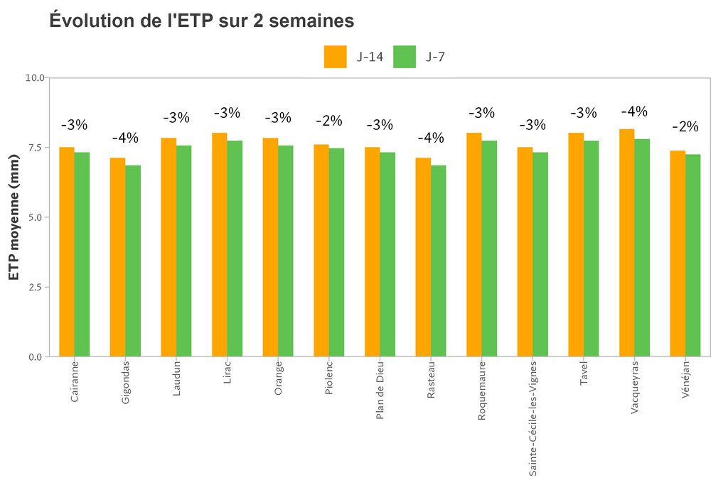

# Bilan hydrique et FTSW

Vous trouverez dans cette partie la modélisation des bilans hydriques et de la FTSW, ou la fraction d’eau disponible dans le sol. Ce sont des données modélisées et peuvent donc présenter des différences avec la réalité.

*Bilans hydriques* : Ci-dessous, le Bilan Hydrique pour les parcelles du réseau. Pour plus d’informations sur les bilans hydriques voir la fiche : [**Lire un bilan hydrique**](https://www.institut-rhodanien.com/article/fiche-technique-lire-un-bilan-hydrique)

*FTSW* : Proportion d’eau disponible dans le sol Les pluies depuis le début de l’année ayant été importants, le pourcentage initial d’eau disponible dans le sol a été estimé à environ 100%.Ces informations sont confirmées par les mesures de sondes capacitives. Ces graphiques représentent la proportion d’eau disponible dans le sol théorique (calculée en fonction des données météo).

Vous pouvez cliquer sur les graphiques pour les agrandir.

### Cairanne

[figure not shown]

### Gigondas

[figure not shown]

### Laudun

[figure not shown]

### Lirac

[figure not shown]

### Orange

[figure not shown]

### Piolenc

[figure not shown]

### Plan de Dieu

[figure not shown]

### Rasteau

[figure not shown]

### Roquemaure

[figure not shown]

### Tavel

[figure not shown]

### Vacqueyras

[figure not shown]

### Vénéjan

[figure not shown]

# Suivi d’apex

### Vue d’ensemble

L’observation des apex permet d’estimer le niveau de stress hydrique de la vigne.  
Consultez ici la fiche explicative de la méthode des apex : [**Fiche technique - La méthode des apex**](https://www.institut-rhodanien.com/article/fiche-technique-la-methode-des-apex)

La vigne ralentit naturellement sa croissance végétative lorsque la véraison commence. Les fruits deviennent les organes puits auxquels sont aloués la plupart des ressources notamment l’eau. Par conséquent, la croissance des apex est réduite mais la contrainte hydrique n’en est plus la seule responsable. Cela rend difficile l’interprétation des apex, d’où l’arrêt du suivi des apex.

# Suivi des sondes capacitives

Des sondes capacitives ont été installées sur le réseau cette année. Ces sondes nous donnent le pourcentage d’humidité par horizons de sols. Il faut noter que d’une parcelle à une autre, les % peuvent varier notamment de part la texture du sol qui impacte la capacité du sol à retenir l’eau. Il peut être plus intéressant dans un premier temps, d’observer l’évolution des courbes et leur tendance générale pour savoir si le sol se déssèche. Certains horizons présentent une humidité très petite, parfois incohérente avec le reste des horizons, qui peut s’expliquer par la présence de cailloux ou de bulles d’air. Prochainement, seront intégrés des graphiques de stock (en mm), pour faciliter la compréhension.

*Attention, les seuils de capacité au champ, de RFU et flétrissement ont été fixés soit grâce à la texture du sol, soit en prenant compte le pourcentage maximum et minimum des sols cette année. Pour affiner ces seuils, il conviendrait d’avoir un an de données pour plus de précision.*

Pour chaque parcelle, vous trouverez l’humidité moyenne du sol (moyenne des horizons) et le détail par horizon.

### Cairanne

[figure not shown]

### Gigondas

[figure not shown]

### Laudun

[figure not shown]

### Lirac

[figure not shown]

### Orange

[figure not shown]

### Piolenc

[figure not shown]

### Rasteau

[figure not shown]

### Roquemaure

[figure not shown]

### Sainte Cecile

[figure not shown]

### Vacqueyras

[figure not shown]

# Tensiomètre - Vénéjan

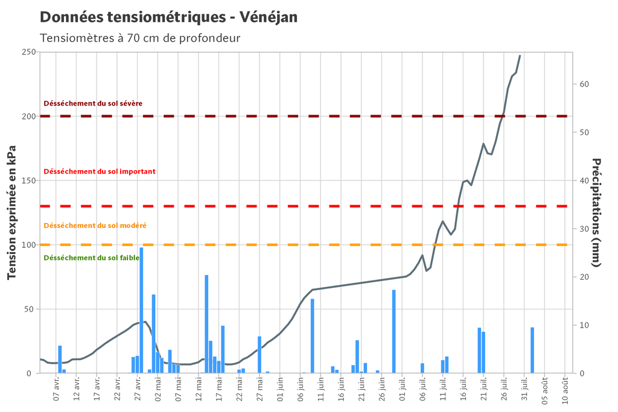